# Research Design: Appendix

## Cluster’s Defining features

The party system is the defining feature, and all other dimensions are arguably its derivatives.

### Party System

First of all, the most important feature is the party system. To my mind, it explains basically all the variation.

```r
typology %>%
  tabyl(cluster, party) %>%
  adorn_percentages("row") %>%
  adorn_pct_formatting() %>%
  as.data.frame() %>%
  kable()
```

| cluster | banned | multiple | single | NA_ |
| --- | --- | --- | --- | --- |
| 1 | 66.6% | 13.1% | 19.0% | 1.3% |
| 2 | 2.2% | 8.2% | 88.9% | 0.7% |
| 3 | 1.0% | 98.5% | 0.1% | 0.5% |

### Military Involvement

Military involvement is relatively evenly distributed across clusters, notwithstanding the dominance of civilian administrations.

```r
typology %>%
  tabyl(cluster, military) %>%
  adorn_percentages("row") %>%
  adorn_pct_formatting() %>%
  as.data.frame() %>%
  kable()
```

| cluster | civilian | corporate | indirect | personal | NA_ |
| --- | --- | --- | --- | --- | --- |
| 1 | 54.9% | 21.7% | 2.4% | 21.0% | 0.0% |
| 2 | 80.6% | 4.0% | 2.3% | 12.9% | 0.1% |
| 3 | 67.5% | 11.4% | 1.7% | 18.7% | 0.7% |

### Legislature Selection

Legislative configuration partially mimics the party system to a large extent:

```r
typology %>%
  tabyl(cluster, legislative) %>%
  adorn_percentages("row") %>%
  adorn_pct_formatting() %>%
  as.data.frame() %>%
  kable()
```

| cluster | largest party controls less than 75% of seats | largest party controls more than 75% of seats | none | nonpartisan | one party or candidate per seat | unelected or appointed | NA_ |
| --- | --- | --- | --- | --- | --- | --- | --- |
| 1 | 0.0% | 0.0% | 58.7% | 10.6% | 3.5% | 22.9% | 4.4% |
| 2 | 0.0% | 0.1% | 0.4% | 0.0% | 95.9% | 2.8% | 0.7% |
| 3 | 41.3% | 30.6% | 6.5% | 1.4% | 6.2% | 8.7% | 5.3% |

### Executive Selection

The same is true for executive selection. For example, first cluster with banned parties does not elect their executives in $\approx 92\%$ of cases.

```r
typology %>%
  tabyl(cluster, executive) %>%
  adorn_percentages("row") %>%
  adorn_pct_formatting() %>%
  as.data.frame() %>%
  kable()
```

| cluster | elected by less than 75% | elected by more than 75% | one party or candidate | selected by a small, unelected body | unelected | NA_ |
| --- | --- | --- | --- | --- | --- | --- |
| 1 | 0.0% | 0.2% | 0.5% | 6.8% | 92.3% | 0.2% |
| 2 | 1.0% | 0.9% | 83.4% | 2.6% | 10.9% | 1.2% |
| 3 | 31.8% | 26.9% | 8.1% | 9.4% | 20.4% | 3.3% |

## Figure from the text

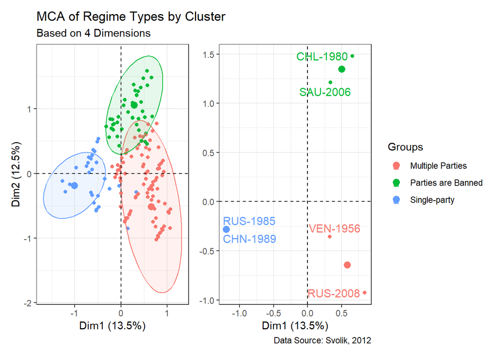

```r
typology = typology %>%
  mutate(cluster_name = case_when(cluster == 1 ~ "Parties are Banned",
                                  cluster == 2 ~ "Single-party",
                                  cluster == 3 ~ "Multiple Parties"))

general = fviz_mca_ind(mca_res,
             label = "none",
             habillage = as.factor(typology$cluster_name),
             addEllipses = TRUE,
             title = "MCA of Regime Types by Cluster") +
  theme_bw() +
  theme(legend.position="none") +
  labs(subtitle = "Based on 4 Dimensions")

examples = fviz_mca_ind(mca_res,
             label = "all",
             select.ind = list(name = c("CHL-1980", "SAU-2006", "CHN-1989", "VEN-1956", "RUS-2008", "RUS-1985")),
             repel = T,
             habillage = as.factor(typology$cluster_name),
             # addEllipses = TRUE,
             title = "MCA of Regime Types by Cluster")  +
  theme_bw() +
  labs(y = NULL,
       title = NULL,
       caption = "Data Source: Svolik, 2012")

general + examples
```